# Bike report PDA

# 1 Exploring business opportunities through Citi Bike Data Analysis

# 2 Documentation

1. How do Citi bike hires vary over time?
2. Do Citi bike hires differ between rider demographic?
3. Do any other patterns exist?
4. What is the geographical spread of the start points of bike hires?

Additional analysis was carried out using supplementary weather that was taken from https://www.visualcrossing.com/ (accessed :06/09/23). Weather data was joined with the inital citi bikes data set to from a single object to enable analysis. A list of the packages use is below and a description of the cleaning carried out is also included.

The author was Calum Young and all analysis was carried out in RStudio 2023.06.1.

```r
# Load required packages and citi bikes dataset

library(tsibbledata)
library(tidyverse)
library(stringr)
library(infer)
library(leaflet)
library(lubridate)

bikes <- nyc_bikes
```

# 3 Data Cleaning

```r
# Separate all date levels into separate columns for start/end of journeys,
# Extract time stamp and convert to time format,
# Calculate journey duration,
# extract age of users.

bikes_clean <- bikes %>%
  mutate(
    day_start = day(start_time),
    month_start = month(start_time, label = T, abbr = F),
    year_start = year(start_time),
    weekday_start = wday(start_time, label = T),
    day_end = day(stop_time),
    month_end = month(stop_time, label = T, abbr = F),
    year_end = year(stop_time),
    weekday_end = wday(stop_time, label = T),
    time_start = hms(str_extract(start_time, "\\d{2}:\\d{2}:\\d{2}" )),
    time_end = hms(str_extract(stop_time, "\\d{2}:\\d{2}:\\d{2}" )),
    duration = difftime(stop_time, start_time),
    date = make_datetime(year_start, month_start, day_start),
    age = 2023 - birth_year
    )

# make a new column splitting age into incremental 5 year group
bikes_clean <- bikes_clean %>%
mutate(age_group = paste0(floor(age / 5) * 5, '-', floor(age / 5) * 5 + 4))


# Build function which rounds time stamp to 60 min intervals so hour of use
# can be inferred.

rounded_time <- function(start_time){
  rounded_time <- round_date(start_time, unit = "60 mins")
  format(rounded_time, format = "%HH %MM %SS")
}

bikes_clean<- bikes_clean %>%
  mutate(
    round_time = as.factor(rounded_time(start_time))
 )

# make a new column which shows the hour day a hire was made
bikes_clean <- bikes_clean %>%
  mutate(hour = as.factor(str_extract(round_time, "\\d{2}")))


# Define orders of days of week for visualisation

bikes_clean <- bikes_clean %>%
  mutate(weekday_start = factor(weekday_start, levels = c("Mon", "Tue", "Wed", "Thu", "Fri", "Sat", "Sun")))
```

## 3.1 Addition of weather data and joining with bike data

```r
# Load in weather dataset
weather <- read_csv("new york 2018-01-01 to 2018-12-31.csv")

# convert date formate
weather <- weather %>%
  mutate(date = dmy(datetime))

# join datasets together
bike_weather <- inner_join(bikes_clean, weather, "date")
```

# 4 Data Visualisation

The first analysis was carried out on journey duration, trends explored were how citi bike usage varies throughout the week, month and year and also throughout an single day. It was hypothesized that during the working week there would be an abundance of journeys around 9am and 5pm of similar duration to coincide with commuters using the bikes to get to work. During the summer months e.g. June to August it was expected that there would be overall more use of the bikes but a lso people using them for longer periods are as visiting tourists explored the city. In contrast, during winter bike journeys overall were expected to decrease and those that did occur would be short in duration. This is due to poor weather conditions making cycling difficult.

## 4.1 Hire Duration

The overall mean hire duration was 12.28 minutes. From the plot below its is clear that customers are on average using citi bikes for longer journeys relative to subscribers throughout the week. Subscribers showed similar daily usages Monday to Thursday, expectantly from commuting journeys. On Fridays subscriber duration increased drastically indicating usage was bike for higher for non-work purposes. As subscribers are already enrolled, we will focus on augmenting the spend by the customer group. As customers are using bikes for longer on Saturdays or Sundays, pricing could be increased to a premium weekend rate. A short term weekend subscription could then be offered as an alternative. This would introduce customers to the benefits of the subscription service and potentially hold them as long term account holders.

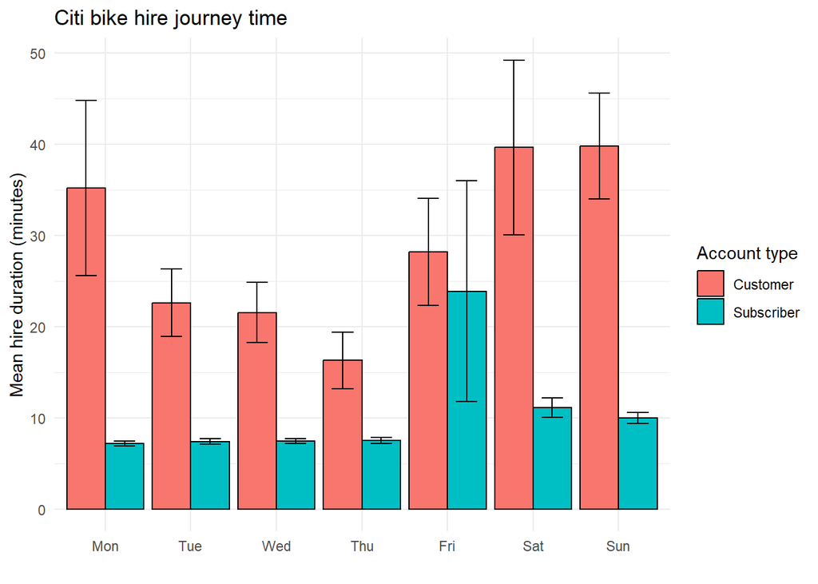

```r
# calculate average journey duration
mean_duration <- bikes_clean %>%
  summarise(mean_duration = mean(duration))

# calulate summary stats to provide std error bars
duration_stats_day <- bikes_clean %>%
  group_by(weekday_start, type) %>%
  summarise(
    mean_day_duration = mean(duration),
    SE = sd(duration) / sqrt(length(duration)),
    SD = sd(duration)
  )

# build plot showing mean journey duration between account type during each week
# day.
duration_stats_day %>%
  ggplot(aes(x = weekday_start, y = mean_day_duration, fill = type)) +
  geom_bar(stat = "identity", colour = "black", position = position_dodge(width = 0.9)) +
  geom_errorbar(aes(ymin = mean_day_duration - SE, ymax = mean_day_duration + SE), position = position_dodge(width = 0.9), width = 0.5) +
  theme_minimal() +
  labs(
    title = "Citi bike hire journey time",
    y = "Mean hire duration (minutes)",
    x = "",
    fill = "Account type"
  )
```

## 4.2 Weekly Hires

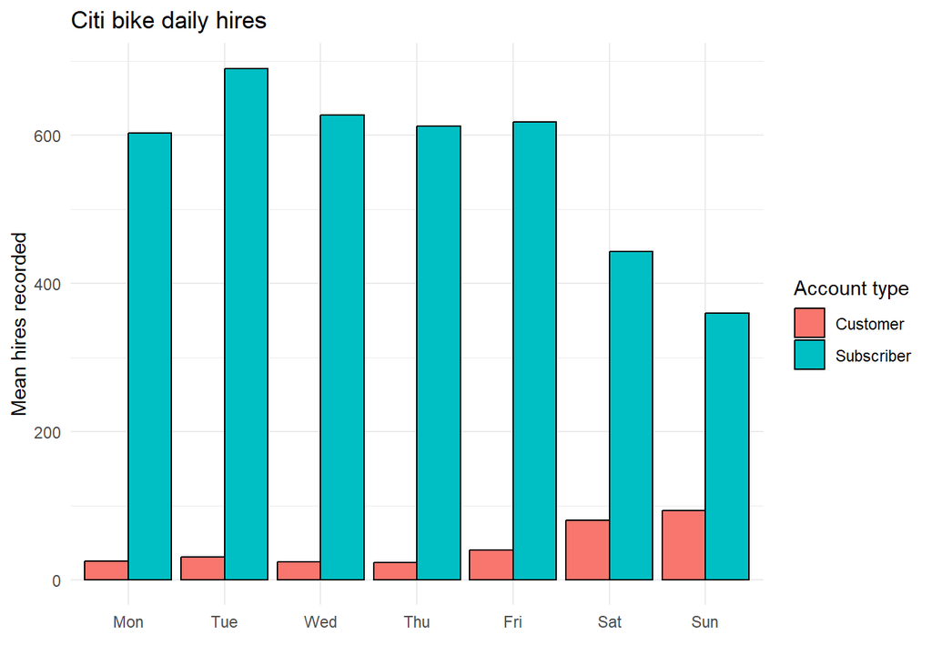

```r
# count number of rows to show number of daily hires within each weekday
daily_usage <- bikes_clean %>%
  group_by(weekday_start, type) %>%
  summarise(
    count = n())

# build plot showing daily average of citi bike hires
daily_usage %>%
  ggplot(aes(x = weekday_start, y = count, fill = type)) +
  geom_bar(stat = "identity", colour = "black", position = "dodge") +
  theme_minimal() +
  labs(
    title = "Citi bike daily hires",
    y = "Mean hires recorded",
    x = "",
    fill = "Account type"
  )
```

## 4.3 Yearly Hire Patterns between gender

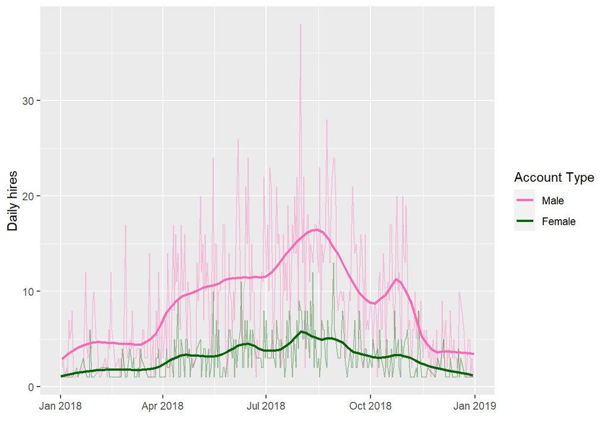

```r
# summarise number of hires grouped by gender - unknown category excluded as
# value would not add anything to analysis.
full_usage <- bikes_clean %>%
  filter(gender != "Unknown") %>%
  group_by(gender, date) %>%
  summarise(daily_count = n())

# Build plot showing yearly usage of citibike split between male/female gender
# groups
full_usage %>%
  ggplot(aes(x = date, y = daily_count, colour = gender)) +
  geom_line(alpha = 0.35) +
  geom_smooth(se = F, span = 0.2) +
  labs(
    y = "Daily hires",
    x = "",
    colour = "Account Type"
  ) +
  scale_colour_manual(values = c("hotpink", "darkgreen"))
```

```r
full_usage %>%
  summarise(max = max(daily_count))
```

| gender | max |
| --- | --- |
| Male | 38 |
| Female | 13 |

## 4.4 Usage between age groups

The age of the average user was 40 for females and 42 for males. As cycling is a healthy and cheap means of transport, business strategies that focus on the younger population should be increased. In the lowest age bracket 20-24, there were only 3 recorded hires in 2018, all of which were male. In order to increase the use of citi bikes by younger individuals strategies could be introduced that make it more appealing. For example, student discounts, a reward scheme where x number of miles accumulated gives a free coffee etc. Getting a younger population introduced to the system early on ensures a long term customer. Surveys should be carried out why young people aren’t using the bikes, is the cost too high to rent regularly or do they own their own. It is advised to investigate if having more stations closer to schools and university campuses increase usage.

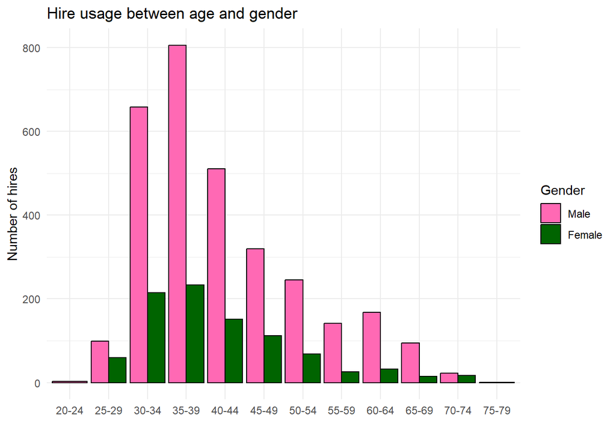

```r
# Counts number of hires of each gender and within incremental age groups
gender_age <- bikes_clean %>%
  filter(gender != "Unknown") %>%
  group_by(age_group, gender) %>%
  summarise(use = n())

# builds a plots showing hire usage between age groups and split between male/
# female
gender_age %>%
  ggplot(aes(x = age_group, y = use, fill = gender)) +
  geom_bar(stat = "identity", colour = "black", position = position_dodge(width = 0.9)) +
  theme_minimal() +
  labs(
    title = "Hire usage between age and gender",
    y = "Number of hires",
    x = "",
    fill = "Gender"
  ) +
  scale_fill_manual(values = c("hotpink", "darkgreen"))
```

```r
# report mean age of users in males and females.
bikes_clean %>%
  filter(gender != "Unknown") %>%
  group_by(gender) %>%
  summarise(mean_age = mean(age))
```

| gender | mean_age |
| --- | --- |
| Male | 42.05735 |
| Female | 40.86452 |

## 4.5 Hourly usage between genders

As predicted, peak usage occurs around business rush hours. As was seen before the is a large disparity between hire usage between genders with males continually superseding females in usage at any hour of the day. Between late evening and early morning hours 10pm - 5am, female usage is at an all time low. This may be due to safety concerns and again a lack of suitable cycling infrastructure. Improving cycling routes with streetlights may increase female uage of the system after hours. Publicity campaigns that promote cycling in pairs or a group may also increase likelihood that females use the service as a means of returning home late at night.

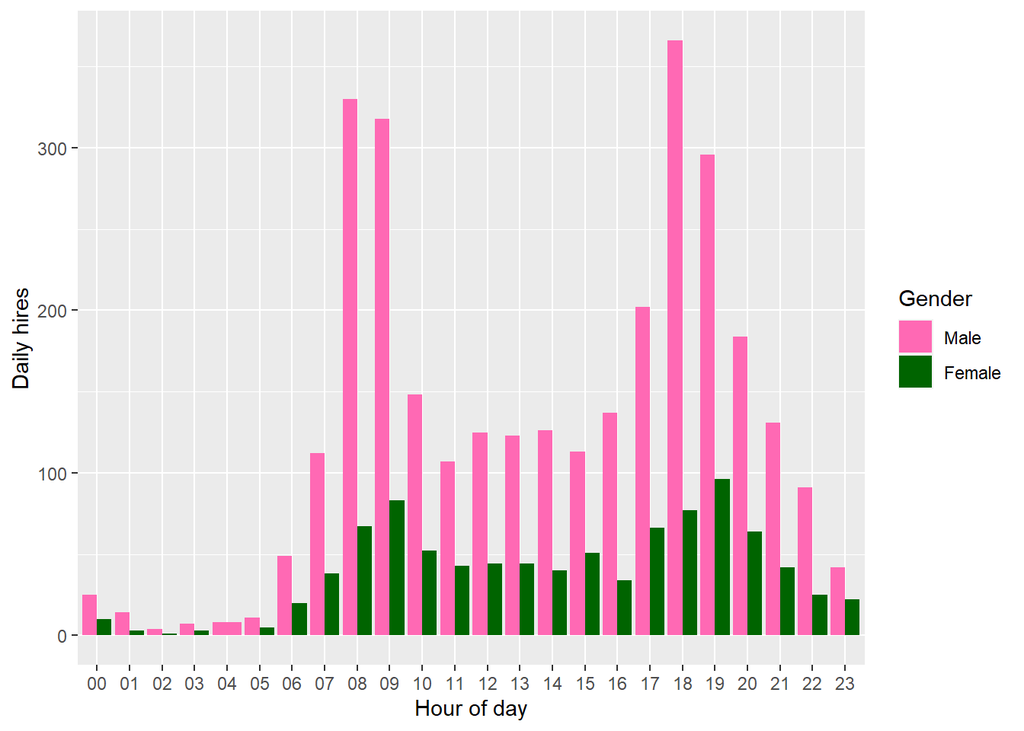

```r
# collates the times hires were made and split between each gender
time_gender <-
  bikes_clean %>%
  group_by(hour, gender) %>%
  summarise(hour_count = n())

# build plot summarizing the number of hires at each hour of the day between male/
# female
time_gender %>%
  filter(gender != "Unknown") %>%
  ggplot(aes(x = hour, y = hour_count, fill = gender)) +
  geom_col(position = "dodge") +
  labs(
    y = "Daily hires",
    x = "Hour of day",
    fill = "Gender"
  ) +
  scale_fill_manual(values = c("hotpink", "darkgreen"))
```

## 4.6 What is the geographical spread of start points of bike hires?

The geographical spread of citi bike journey starts within this dataset is dispersed mainly within the Jersey City district although there are many or pockets scattered in the surrounding area. The map below shows this distribution and the diameter of blue circles is indicative of how many hires began at each site; the larger the circle the more that station is used. This is highly indicative of sites that used most often and therefore may benefit customers most if they are enlarged and more bikes are available to hire. For example the station at the corner of Christopher Columbus Drive and Grove Street had 434 journey starts which was 1.5 times more than the second most used station at West Hamilton place. In contrast, the station at New Jersey City University was only used once as a start point indicating it is not in a viable location and could be more effective if located elsewhere.

The second map shows the stations where journeys ended and the maps are highly similar showing again which stations are most utilized throughout this region of the city.

```r
# This chunk builds up geospatial data of the start points of hires
station_stat <- bike_weather %>%
  group_by(start_lat, start_long) %>%
  summarise(count = n())

# this builds interactive plot showing location of bike start points, denoted
# by blue circles, the larger the circle shows the number of bikes at that
# specific station
station_stat %>%
  leaflet() %>%
  addTiles() %>%
  addCircleMarkers(lng = ~start_long,
                   lat = ~start_lat,
                   radius = ~count/20,
    popup = ~paste("Count:", count)
  )
```

[interactive chart not shown]

```r
# Same setup as above but shows end stations in red circles
station_end <- bike_weather %>%
  group_by(end_lat, end_long) %>%
  summarise(count = n())


station_end %>%
  leaflet() %>%
  addTiles() %>%
  addCircleMarkers(lng = ~end_long,
                   lat = ~end_lat,
                   radius = ~count/20,
    popup = ~paste("Count:", count),
    color = "red"
  )
```

[interactive chart not shown]

## 4.7 Additional: Is there a relationship between citi bike hires and weather conditions?

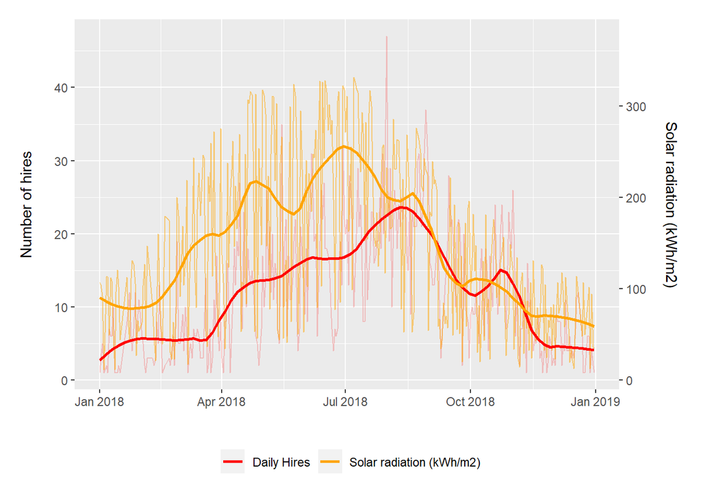

```r
# pre-marginalizing of forthcoming plots
plot_dimensions <- theme(
  plot.margin = margin(0.5, 0.5, 0.5, 0.5, unit = "cm")
)

# builds a plot which shows year on the x axis, number of hires on the y and
# daily solar radiation on the z
solar <- bike_weather %>%
  group_by(solarradiation, date) %>%
  summarise(daily_count = n()) %>%
  ungroup() %>%
  ggplot(aes(x = date)) +
  geom_line(aes(y = daily_count, color = "Daily Hires"), alpha = 0.2) +
  geom_line(aes(y = solarradiation / 8, color = "Solar radiation (kWh/m2)"), alpha = 0.5) +
  geom_smooth(aes(y = daily_count, color = "Daily Hires"), se = FALSE, span = 0.2) +
  geom_smooth(aes(y = solarradiation / 8, color = "Solar radiation (kWh/m2)"), se = FALSE, span = 0.2) +
  scale_y_continuous(
    sec.axis = sec_axis(~ . * 8, name = "Solar radiation (kWh/m2)\n"), name = "Number of hires\n",
    breaks = seq(0, 40, by = 10),
    labels = seq(0, 40, by = 10)
  ) +
  theme(legend.position = "bottom")+

  labs(
    y = "Daily Hires",
    x = "",
    color = ""
  ) +
  scale_color_manual(
    values = c("Daily Hires" = "red", "Solar radiation (kWh/m2)" = "orange")
  ) +
  plot_dimensions

solar
```

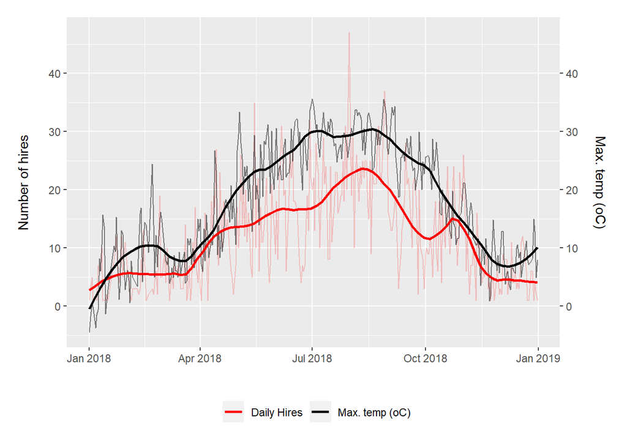

```r
## builds a plot which shows year on the x axis, number of hires on the y and
# daily temperature maximums radiation on the z

temp <- bike_weather %>%
  group_by(tempmax, date) %>%
  summarise(daily_count = n()) %>%
  ungroup() %>%
  ggplot(aes(x = date)) +
  geom_line(aes(y = daily_count, color = "Daily Hires"), alpha = 0.2) +
  geom_line(aes(y = tempmax / 1, color = "Max. temp (oC)"), alpha = 0.5) +
  geom_smooth(aes(y = daily_count, color = "Daily Hires"), se = FALSE, span = 0.2) +
  geom_smooth(aes(y = tempmax / 1, color = "Max. temp (oC)"), se = FALSE, span = 0.2) +
  scale_y_continuous(
    sec.axis = sec_axis(~ . * 1, name = "Max. temp (oC)\n"), name = "Number of hires\n",
    breaks = seq(0, 40, by = 10),
    labels = seq(0, 40, by = 10)
  ) +
  labs(
    y = "Daily Hires",
    x = "",
    color = ""
  ) +
  scale_color_manual(
    values = c("Daily Hires" = "red", "Max. temp (oC)" = "black")
  ) + plot_dimensions+
  theme(legend.position = "bottom")

temp
```

# 5 Ethics statement

The data set used here has been carefully analysed as to avoid any ethical infractions. To ensure the protection and privacy of individuals, user information was anonymity and aggregated to prevent single identifications from being made. The report shows the entire code used to ensure transparency in the methods used is shown. The data was taken from external sources hence the quality and accuracy is dependent on that source. No new rows were added during analysis. Recommendations based on age and gender and purely from a generalized economic perspective and in no way isolate any individuals from any one demographic.

# 6 Conclusion

This analysis of Citi Bike data provides an data driven source of insights for optimizing this bike-sharing service. By focusing on improving gender equity, targeting younger populations, enhancing safety measures, and expanding strategically in response to geographical insights, Citi Bike can strengthen its position and foster sustainable growth in the urban mobility market.